# Lesson 5

### Multivariate Data

Notes:

```r
setwd("~/MOOCs/Udacity/R Data Science")
pf <- read.csv("pseudo_facebook.tsv", sep = "\t")
require(ggplot2)
require(gridExtra)
```

### Moira Perceived Audience Size Colored by Age

Notes: Moira tried breaking out the perceived audience size by age to see if she could see any pattersn. She made color the indicator. It turned out that there was no signal in the data.

### Third Qualitative Variable

Notes:

```r
require(dplyr)
pf.fc_by_age_gender <- pf %>%
        filter(!is.na(gender)) %>%
        group_by(age, gender) %>%
        summarize(
                mean_friend_count = mean(friend_count),
                median_friend_count = median(friend_count),
                n = n()
        ) %>%
        ungroup() %>%
        arrange(age)
```

### Plotting Conditional Summaries

Notes:

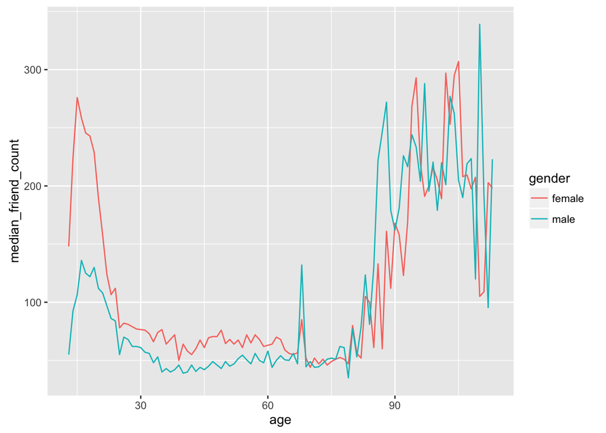

```r
ggplot(aes(x = age, y = median_friend_count), data = pf.fc_by_age_gender) +
        geom_line(aes(color = gender))
```

### Thinking in Ratios

Notes:

### Reshaping Data

Notes:

```r
library(reshape2)
```

```r
require(dplyr)
require(tidyr)
#pf.fc_by_age_gender.wide <- subset(pf.fc_by_age_gender[c('age', 'gender', 'median_friend_count')],                   !is.na(gender)) %>%
#    spread(gender, median_friend_count) %>%
#    mutate(ratio = male / female)

#head(pf.fc_by_age_gender.wide)

pf.fc_by_age_gender.wide <- dcast(pf.fc_by_age_gender,
                                  age ~ gender,
                                  value.var = 'median_friend_count')

head(pf.fc_by_age_gender.wide)
```

```
##   age female  male
## 1  13  148.0  55.0
## 2  14  224.0  92.5
## 3  15  276.0 106.5
## 4  16  258.5 136.0
## 5  17  245.5 125.0
## 6  18  243.0 122.0
```

### Ratio Plot

Notes:

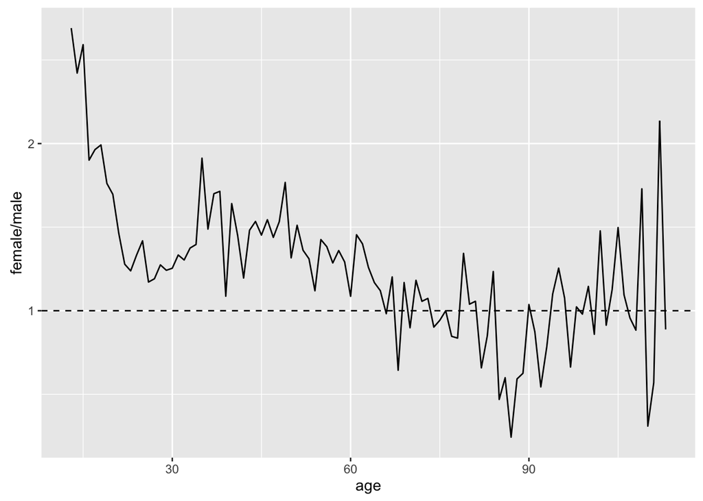

```r
ggplot(aes(x = age, y = female / male), data = pf.fc_by_age_gender.wide) +
        geom_line() +
        geom_hline(aes(yintercept = 1), linetype = 2)
```

### Third Quantitative Variable

Notes:

```r
pf$year_joined <- floor(2014 - (pf$tenure / 365))
```

### Cut a Variable

Notes:

```r
summary(pf$year_joined)
```

```
##    Min. 1st Qu.  Median    Mean 3rd Qu.    Max.    NA's
##    2005    2012    2012    2012    2013    2014       2
```

```r
table(pf$year_joined)
```

```
##
##  2005  2006  2007  2008  2009  2010  2011  2012  2013  2014
##     9    15   581  1507  4557  5448  9860 33366 43588    70
```

```r
pf$year_joined.bucket <- cut(pf$year_joined, breaks = c(2004, 2009, 2011, 2012, 2014))
```

### Plotting it All Together

Notes: It looks like our instincts were right – friend counts for longer tenured users is higher than the friend counts of more recent users who joined Facebook.

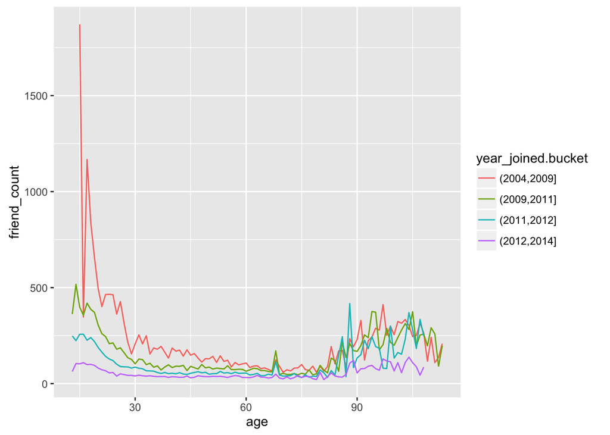

```r
ggplot(aes(x = age, y = friend_count), data = subset(pf, !is.na(year_joined.bucket))) +
        geom_line(aes(color = year_joined.bucket), stat = "summary", fun.y = median)
```

### Plot the Grand Mean

Notes: In this plot, we are looking at the mean instead of the median. Plotting the grand mean reminds us that much of this data is reliant on people who joined in recent cohorts. The grand mean is a lot closer to the more recent cohorts than the one from 2004 - 2009.

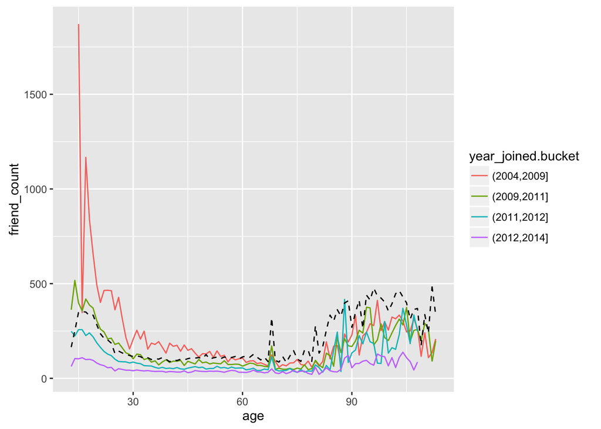

```r
ggplot(aes(x = age, y = friend_count), data = subset(pf, !is.na(year_joined.bucket))) +
        geom_line(aes(color = year_joined.bucket), stat = "summary", fun.y = median) +
        geom_line(stat = "summary", fun.y = mean, linetype = 2)
```

### Friending Rate

Notes:

What is the median friend rate? 0.2205

What is the maximum friend rate? 417.0000

```r
with(subset(pf, tenure >= 1), summary(friend_count / tenure))
```

```
##     Min.  1st Qu.   Median     Mean  3rd Qu.     Max.
##   0.0000   0.0775   0.2205   0.6096   0.5658 417.0000
```

### Friendships Initiated

Notes: How many friendships are initiated per day across users of various tenure? Using the mean of friendships initiated per day, plot the line for users of each tenure. It looks like users with one day of tenure average a little under 10 friendships per day, while users of longer tenure initiate less than one friendship per day of tenure. Users tend to make a lot of friends early on after signing up for Facebook, and then taper off their friending spree. This graph is a bit noisy though. I wonder what we could do to minimize that noise?

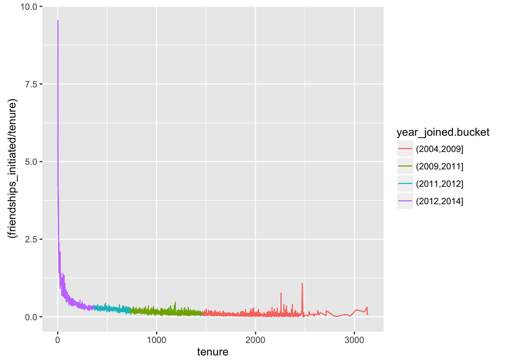

```r
ggplot(aes(x = tenure, y = (friendships_initiated / tenure)), data = subset(pf, tenure >= 1)) +
        geom_line(aes(color = year_joined.bucket), stat = "summary", fun.y = mean)
```

### Bias-Variance Tradeoff Revisited

Notes: Friendships initiated still declines as tenure increases. But in the first four graphs, we can see that we can manually smooth our graph by rounding off the tenure variable. Or, we could use geom_smooth instead of geom line to let R’s default values figure out the optimal way to smooth the line.

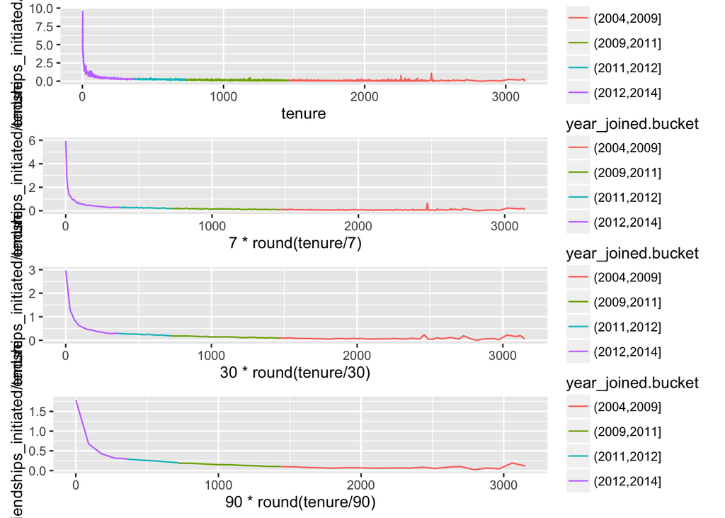

```r
p1 <- ggplot(aes(x = tenure, y = friendships_initiated / tenure),
       data = subset(pf, tenure >= 1)) +
  geom_line(aes(color = year_joined.bucket),
            stat = 'summary',
            fun.y = mean)

p2 <- ggplot(aes(x = 7 * round(tenure / 7), y = friendships_initiated / tenure),
       data = subset(pf, tenure > 0)) +
  geom_line(aes(color = year_joined.bucket),
            stat = "summary",
            fun.y = mean)

p3 <- ggplot(aes(x = 30 * round(tenure / 30), y = friendships_initiated / tenure),
       data = subset(pf, tenure > 0)) +
  geom_line(aes(color = year_joined.bucket),
            stat = "summary",
            fun.y = mean)

p4 <- ggplot(aes(x = 90 * round(tenure / 90), y = friendships_initiated / tenure),
       data = subset(pf, tenure > 0)) +
  geom_line(aes(color = year_joined.bucket),
            stat = "summary",
            fun.y = mean)

grid.arrange(p1, p2, p3, p4, ncol = 1)
```

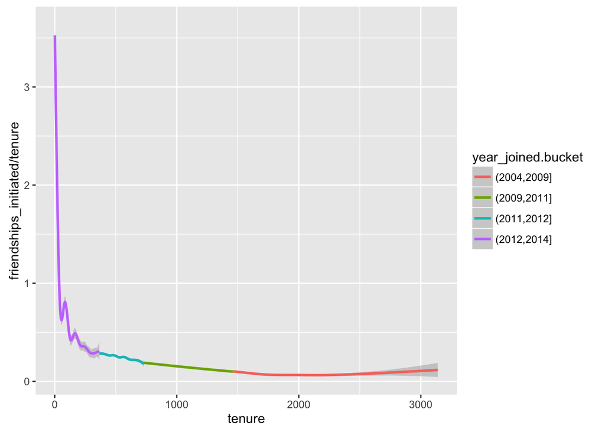

```r
ggplot(aes(x = tenure, y = friendships_initiated / tenure),
       data = subset(pf, tenure > 0)) +
  geom_smooth(aes(color = year_joined.bucket))
```

### Sean’s NFL Fan Sentiment Study

Notes: Sean Taylor did a nice analysis to look at sentiment of NFL fans over time. He had to combine a couple graphs, to get something not too smooth, yet not too noisy. He used splines partially.

### Introducing the Yogurt Data Set

Notes: Yogurt data that is structured differently than the Facebook data. This data has many rows per household, one for each purchase occasion. One might call it “microdata.”

### Histograms Revisited

Notes: We want to convert the id variable into a factor, because we really won’t be doing any math with the id, even though it is a number.

```r
yo <- read.csv("yogurt.csv")
str(yo)
```

```
## 'data.frame':    2380 obs. of  9 variables:
##  $ obs        : int  1 2 3 4 5 6 7 8 9 10 ...
##  $ id         : int  2100081 2100081 2100081 2100081 2100081 2100081 2100081 2100081 2100081 2100081 ...
##  $ time       : int  9678 9697 9825 9999 10015 10029 10036 10042 10083 10091 ...
##  $ strawberry : int  0 0 0 0 1 1 0 0 0 0 ...
##  $ blueberry  : int  0 0 0 0 0 0 0 0 0 0 ...
##  $ pina.colada: int  0 0 0 0 1 2 0 0 0 0 ...
##  $ plain      : int  0 0 0 0 0 0 0 0 0 0 ...
##  $ mixed.berry: int  1 1 1 1 1 1 1 1 1 1 ...
##  $ price      : num  59 59 65 65 49 ...
```

```r
yo$id <- factor(yo$id)
str(yo)
```

```
## 'data.frame':    2380 obs. of  9 variables:
##  $ obs        : int  1 2 3 4 5 6 7 8 9 10 ...
##  $ id         : Factor w/ 332 levels "2100081","2100370",..: 1 1 1 1 1 1 1 1 1 1 ...
##  $ time       : int  9678 9697 9825 9999 10015 10029 10036 10042 10083 10091 ...
##  $ strawberry : int  0 0 0 0 1 1 0 0 0 0 ...
##  $ blueberry  : int  0 0 0 0 0 0 0 0 0 0 ...
##  $ pina.colada: int  0 0 0 0 1 2 0 0 0 0 ...
##  $ plain      : int  0 0 0 0 0 0 0 0 0 0 ...
##  $ mixed.berry: int  1 1 1 1 1 1 1 1 1 1 ...
##  $ price      : num  59 59 65 65 49 ...
```

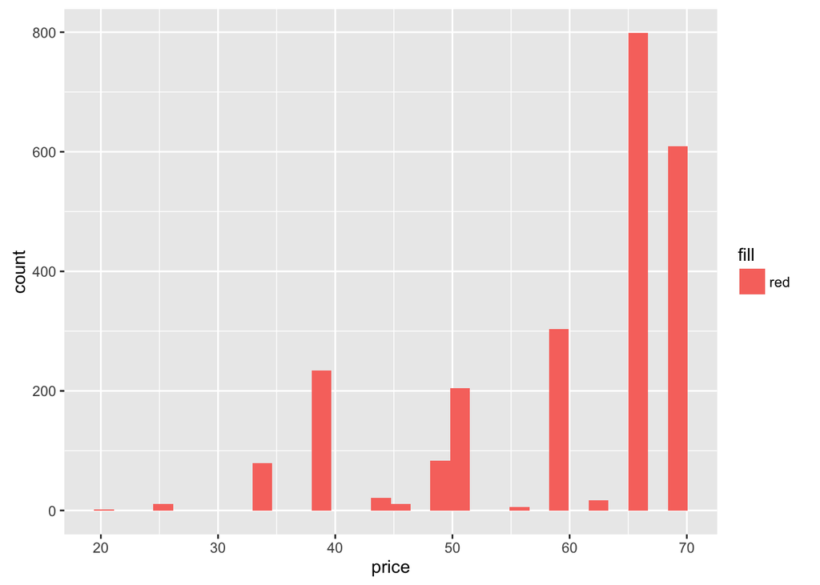

```r
ggplot(aes(x = price, fill = "red"), data = yo) +
        geom_histogram()
```

### Number of Purchases

Notes: Transform is a generic function that creates a new variable based off a set of current variables. It returns a dataframe, so it needs to get re-saved back to the data frame that was originally called.

```r
summary(yo$price)
```

```
##    Min. 1st Qu.  Median    Mean 3rd Qu.    Max.
##   20.00   50.00   65.04   59.25   68.96   68.96
```

```r
length(unique(yo$price))
```

```
## [1] 20
```

```r
table(yo$price)
```

```
##
##    20 24.96 33.04  33.2 33.28 33.36 33.52 39.04    44 45.04 48.96 49.52
##     2    11    54     1     1    22     1   234    21    11    81     1
##  49.6    50 55.04 58.96    62 63.04 65.04 68.96
##     1   205     6   303    15     2   799   609
```

```r
yo <- transform(yo, all.purchases = strawberry + blueberry + pina.colada + plain + mixed.berry)
```

### Prices over Time

Notes: To look at a time series plot, we want to compensate for overplotting by providing an alpha value. We use geom_jitter to space ou the observations a bit. It looks like the most prices stay stable for three periods of time. Time zero through 9800 seems to be one price, 9800 through 10100 another, and 10100 through the end of the time series a third higher price. The yogurt company must be increasing price over time. The points below the lines might be customers using coupons to lower the price of the yogurt.

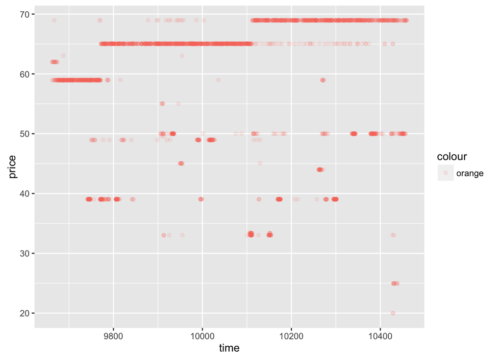

```r
ggplot(aes(x = time, y = price), data = yo) +
        geom_jitter(aes(color = "orange"), alpha = 1/10)
```

### Sampling Observations

Notes: When working with data that contains multiple observations for the same units, it is often useful to work with a sample of those units in order to make it easy to display the raw data for that sample. Here, we might want to look at a sample of households to look at it in more detail.

### Looking at Samples of Households

Notes: We use levels because that will only pick ids from a unique list of ids – there will be no repicking the same id. It looks like there is a lot of variation among the second sample that I took. I can’t honestly tell if there is a patter between any of the customer’s behaviors.

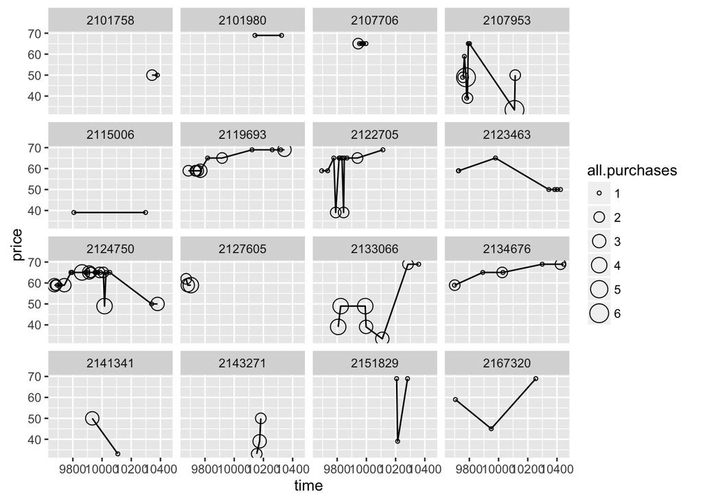

```r
set.seed(4230)

sample.ids <- sample(levels(yo$id), 16)

ggplot(aes(x = time, y = price), data = subset(yo, id %in% sample.ids)) +
        geom_line() +
        facet_wrap( ~ id) +
        geom_point(aes(size = all.purchases), shape = 1)
```

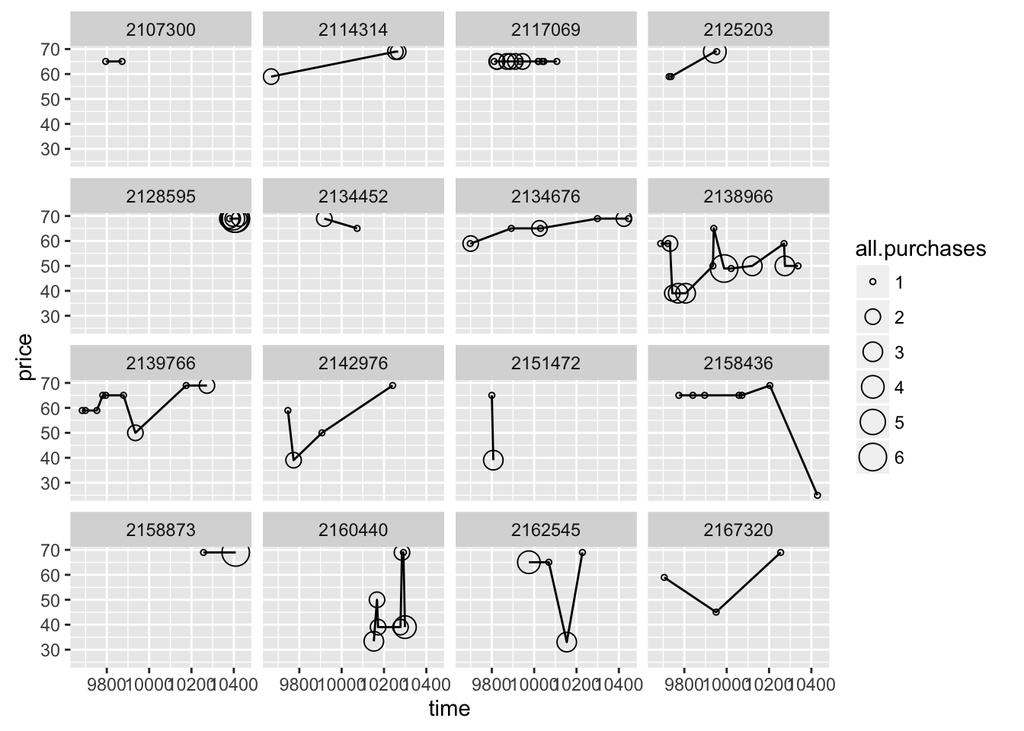

```r
set.seed(42)

sample.ids2 <- sample(levels(yo$id), 16)

ggplot(aes(x = time, y = price), data = subset(yo, id %in% sample.ids2)) +
        geom_line() +
        facet_wrap( ~ id) +
        geom_point(aes(size = all.purchases), shape = 1)
```

```r
ggsave("yogurtplot.png")
```

### The Limits of Cross Sectional Data

Notes:

### Many Variables

Notes: We want the data to speak to identify variables of interest. Scatterplot matrices are particularly useful for this when there are two quantitative variables.

### Scatterplot Matrix

Notes:

```r
library(GGally)
```

[figure not shown]

```r
theme_set(theme_minimal(20))

set.seed(1836)
pf_subset <- pf[, c(3:15)]
ggpairs(pf_subset[sample.int(nrow(pf_subset), 1000), ], axisLabels = 'internal')
```

```r
ggsave("ggpairsplot.png")
names(pf_subset)
```

```
##  [1] "dob_day"               "dob_year"
##  [3] "dob_month"             "gender"
##  [5] "tenure"                "friend_count"
##  [7] "friendships_initiated" "likes"
##  [9] "likes_received"        "mobile_likes"
## [11] "mobile_likes_received" "www_likes"
## [13] "www_likes_received"
```

### Even More Variables

Notes:

### Heat Maps

Notes:

```r
nci <- read.table("nci.tsv")
colnames(nci) <- c(1:64)
```

```r
nci.long.samp <- melt(as.matrix(nci[1:200,]))
names(nci.long.samp) <- c("gene", "case", "value")
head(nci.long.samp)
```

```
##   gene case  value
## 1    1    1  0.300
## 2    2    1  1.180
## 3    3    1  0.550
## 4    4    1  1.140
## 5    5    1 -0.265
## 6    6    1 -0.070
```

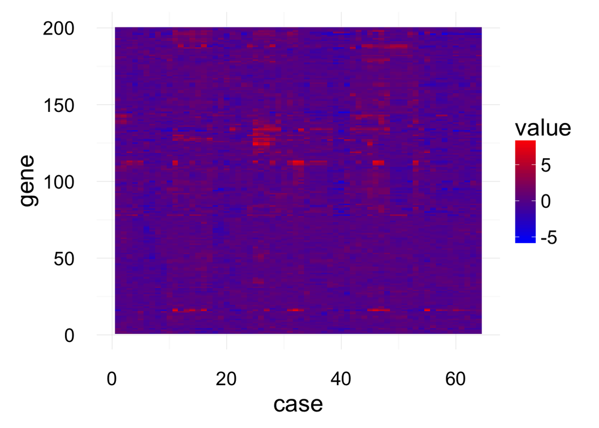

```r
ggplot(aes(y = gene, x = case, fill = value),
  data = nci.long.samp) +
  geom_tile() +
  scale_fill_gradientn(colours = colorRampPalette(c("blue", "red"))(100))
```

### Analyzing Three of More Variables

Reflection: I learned how to look at multiple variables together. I learned how to take data with multiple observations per customer in the yogurt set and plot the data over time. I learned how to sample data using levels of an id key. I learned how to change the data of a geom point so that the size represented the value being plotted over a given price over time. I learned how to create aggreate variables with ‘transform.’ I learned how to transform variables to create new variables, like creating the year joined variable in the Facebook data. I learned how to create different buckets of data, which contain different sizes of data. I learned how to add grand means to plots over means for different bucketed data. I learned how to make summary data, grouped by different variables. I learned how to take data and dcast it so that it shows up in a wide format – taking a variable that is faceted over two categorical variables (like age and gender) and then make it so that one of those categorical variables’ values all become column variables, and the value in the dataframe is a quantitative value associated with the categorical variables – that can be useful when trying to create ratio graphs.

Click **KnitHTML** to see all of your hard work and to have an html page of this lesson, your answers, and your notes!